# Predicting protein type from X-ray diffraction data

Siddharth Sabata

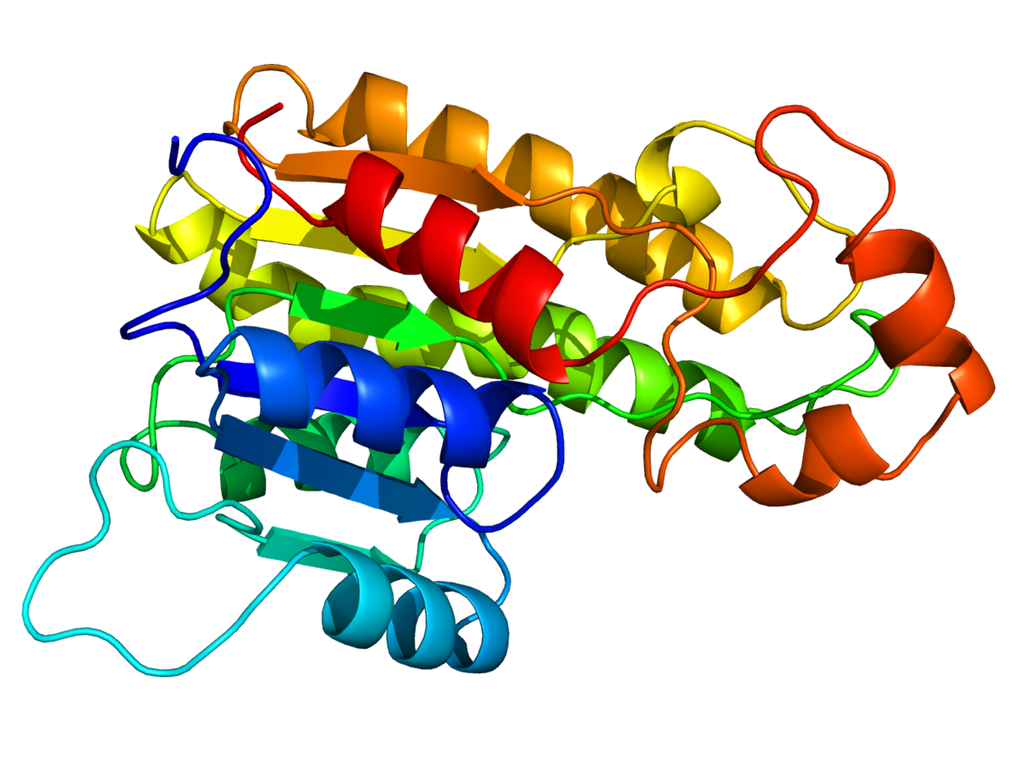

# Introduction

The aim of this project is to develop a model that predicts protein type based off of X-ray diffraction measurements.

### What are proteins?

Proteins are complex biomolecules essential to all living organisms. Composed of amino acids, they play a critical role in biological processes such as cell signaling, immune responses, and metabolic functions. Protein structures are heavily linked to their function. Understanding protein structures is a problem that can give important insights that will help better understand diseases, drug targets, and many more applications in the biotechnology realm.

### What is X-Ray diffraction?

A powerful technique for figuring out a crystal’s atomic and molecular structure is X-ray diffraction (XRD). An X-ray beam diffracts into numerous distinct directions when it meets with a material’s crystalline structure. Through the measurement of these diffracted beams’ angles, XRD is able to create a three-dimensional image of the electrons inside the crystal. The mean positions of the atoms in the crystal, their chemical bonds, their disorder, and other details are then determined using this information. Within the study of proteins, X-ray diffraction (XRD) is very important because it helps scientists understand the structures of proteins, which is essential for comprehending their function and interactions with other molecules.

### Why is this model relevant?

Machine learning algorithms for protein classification analysis of X-ray diffraction data are particularly relevant. These models can be faster and more accurate in determining the function of a protein based off structural data. Scientists can simply use a machine learning model to determine what a protein does, instead of long and arduous experiments. This can especially help in the field of drug discovery, where speed is sometimes key as seen during the COVID-19 pandemic.

### Project roadmap

With some background on this project, we can now outline how these models are going to be trained. We’ll first import the [Structural Protein Sequences](https://www.kaggle.com/datasets/shahir/protein-data-set?select=pdb_data_no_dups.csv) Kaggle dataset. Next, the data will be cleaned and some exploratory data analysis will be done. After this, the data will be split into training and testing datasets and subsequently trained with five models. These five are K-nearest neighbors, elastic net, multinomial logistic regression, random forest, and boosted tree models. Lastly, we’ll choose the best performing model and apply it to the testing dataset and see how it performs.

# Exploratory Data Analysis

### Import libraries

```r
library(janitor)
library(tidyverse)
library(tidymodels)
library(ggplot2)
library(corrplot)
library(ggthemes)
library(kableExtra)
library(themis)
library(ranger)
library(xgboost)
library(vip)
tidymodels_prefer()
```

### Import dataset

This dataset contains two files: `pdb_data_no_dups.csv` and `pdb_data_seq.csv`. For this project, we will focus on the first file, `pdb_data_no_dups.csv`, since it contains the X-Ray diffraction data.

```r
# import x-ray diffraction dataset
pdb_data <- read.csv("data/pdb_data_no_dups.csv")

pdb_data %>%
  head()
```

```
##   structureId        classification experimentalTechnique macromoleculeType
## 1        100D        DNA-RNA HYBRID     X-RAY DIFFRACTION    DNA/RNA Hybrid
## 2        101D                   DNA     X-RAY DIFFRACTION               DNA
## 3        101M      OXYGEN TRANSPORT     X-RAY DIFFRACTION           Protein
## 4        102D                   DNA     X-RAY DIFFRACTION               DNA
## 5        102L HYDROLASE(O-GLYCOSYL)     X-RAY DIFFRACTION           Protein
## 6        102M      OXYGEN TRANSPORT     X-RAY DIFFRACTION           Protein
##   residueCount resolution structureMolecularWeight
## 1           20       1.90                  6360.30
## 2           24       2.25                  7939.35
## 3          154       2.07                 18112.80
## 4           24       2.20                  7637.17
## 5          165       1.74                 18926.61
## 6          154       1.84                 18010.64
##           crystallizationMethod crystallizationTempK densityMatthews
```

[output cut: 20 more lines]

### Codebook

This dataset contains 141401 observations with 14 variables.

| Variable | Description |
| --- | --- |
| structureID | Unique identifier used for the [RCSB Protein Data Bank](https://www.rcsb.org/). |
| classification | Class of molecule that is being measured |
| experimentalTechnique | Technique used to gather information about the biomolecule. We’re only going to work with X-ray diffraction (89% of the data has X-ray diffraction data, 126512 observations) |
| macromoleculeType | Type of macromolecule being used. |
| residueCount | The number of amino acid residues present in the sample. A residue is what remains of an amino acid after a water molecule has been removed in a peptide bond formation. |
| resolution | This is one of the most important parameters in X-ray crystallography. It indicates the level of detail of the structure that can be reliably determined. Resolution is typically given in Ångströms (Å)… |
| structureMolecularWeight | Molecular weight of the molecule in Daltons (Da). |
| densityMatthews | Matthews coefficient. Gives an estimate of the solvent content of the crystal and is a ratio of the volume occupied by the protein to the total unit cell volume. High values (above 3.5 Å³/Da) might in… |
| densityPercentSol | Percent of molecule in the solution. |

There are more variables, but they pertain to redundant information and experimental techniques that are not going to be addressed in this project.

### Data cleaning

First, let’s get rid of the DNA and RNA measurements in the dataset.

```r
# first, we're only going to work with protein data
protein_data <- pdb_data %>%
  dplyr::filter(!str_detect(classification, "DNA") & !str_detect(classification, "RNA"))
```

Next, let’s look at how many different types of proteins we have.

```r
# number check unique classifiers
length(unique(protein_data$classification))
```

```
## [1] 4416
```

As we can see here, There are `4416` unique classifiers under the classification section. For this project, we are going to choose the top 10 most prevalent types.

### Create working dataframe

```r
# with the counts of the top classifiers in mind, we're going to keep the top 10 classifiers
protein_data_top10 <- protein_data %>%
  group_by(classification) %>%
  summarise(count=n()) %>%
  arrange(-count) %>%
  slice_head(n=10) %>%
  select(classification)

# creating working dataframe
protein_data <- protein_data %>%
  semi_join(protein_data_top10, by='classification') %>%
  dplyr::filter(experimentalTechnique == 'X-RAY DIFFRACTION') %>%
  select(-c(crystallizationMethod, pdbxDetails, crystallizationTempK, publicationYear,
            experimentalTechnique, macromoleculeType, phValue)) %>%
  na.omit() %>%
  mutate(classification = factor(classification)) %>%
  clean_names()
```

Let’s break down what steps were just taken to create our cleaned dataframe:

1. The dataframe was filtered to only include the top 10 most common protein types.
2. The dataframe was filtered to only keep X-Ray diffraction data.
3. Redundant columns were removed.
4. Rows with `NA` values were removed due to the abundance of data.
5. The `classification` column was turned into a factor for later steps.
6. The names of the variables were standardized into snake case.

Let’s see what our cleaned dataframe looks like.

```r
dim(protein_data)
```

```
## [1] 68903     7
```

We have `7` variables with `68903` observations.

```r
protein_data %>%
  head()
```

```
##   structure_id classification residue_count resolution
## 1         117E      HYDROLASE           572       2.15
## 2         11BA      HYDROLASE           248       2.06
## 3         11BG      HYDROLASE           248       1.90
## 4         11GS    TRANSFERASE           420       2.30
## 5         14GS    TRANSFERASE           420       2.80
## 6         16GS    TRANSFERASE           420       1.90
##   structure_molecular_weight density_matthews density_percent_sol
## 1                   65203.21             2.71               54.69
## 2                   28700.28             2.48               50.36
## 3                   30391.41             2.40               48.68
## 4                   48366.94             2.53               51.44
## 5                   47146.02             2.64               53.43
## 6                   47242.08             2.53               51.42
```

### Check for correlated variables

Before we can begin applying our models, we should check for correlated variables. This step is crucial because correlated variables can throw off our model.

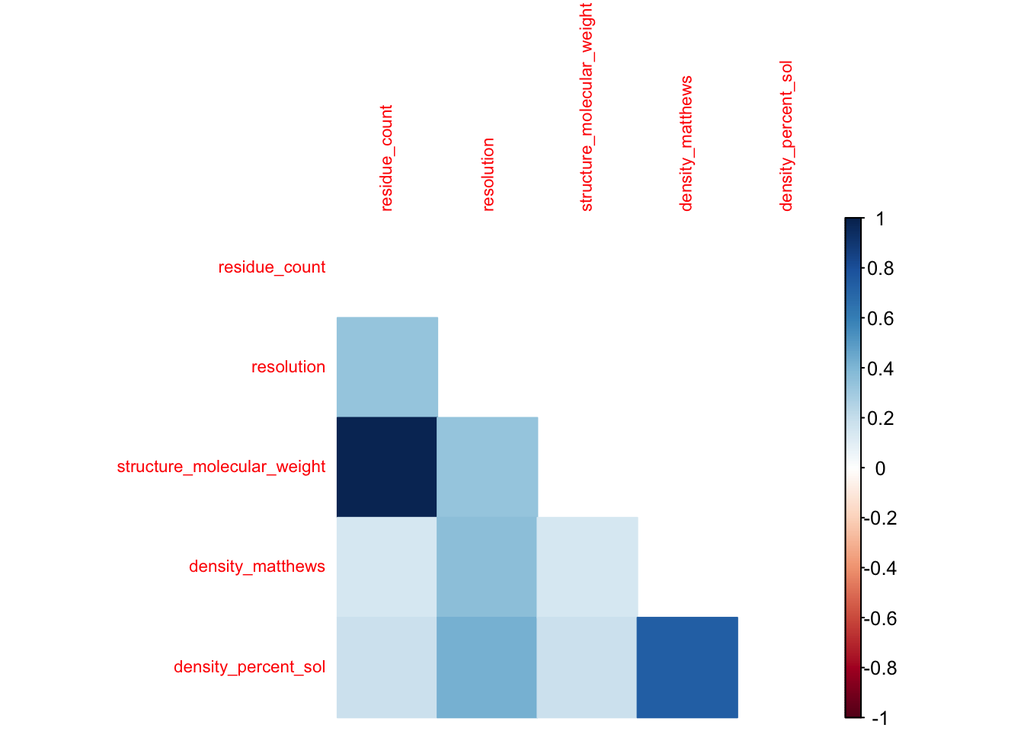

```r
# create correlation matrix
cor_matrix <- cor(protein_data[, sapply(protein_data, is.numeric)])
cor_matrix[upper.tri(cor_matrix, diag = TRUE)] <- NA
corrplot(cor_matrix, na.label = "  ", method = "color", tl.cex = 0.7)
```

```r
cor_matrix
```

```
##                            residue_count resolution structure_molecular_weight
## residue_count                         NA         NA                         NA
## resolution                     0.3377467         NA                         NA
## structure_molecular_weight     0.9889905  0.3394931                         NA
## density_matthews               0.1429763  0.3640611                  0.1459503
## density_percent_sol            0.1855136  0.4285469                  0.1890945
##                            density_matthews density_percent_sol
## residue_count                            NA                  NA
## resolution                               NA                  NA
## structure_molecular_weight               NA                  NA
## density_matthews                         NA                  NA
## density_percent_sol               0.7327565                  NA
```

Based off this plot, we can see that `residue_count` and `structure_molecular_weight` have a strong positive correlation of `0.988`. This is an indication that we should perform principal component analysis (PCA) on these two variables. PCA is a method that is used when multiple variables are positively correlated. This method basically extracts another “component” that accurately represents the two correlated variables in one variable.

### Plot counts of each classification

We also want to check how many of each protein type we have. If a handful of variables are under or over represented, it can skew the training and testing data, thereby skewing our model.

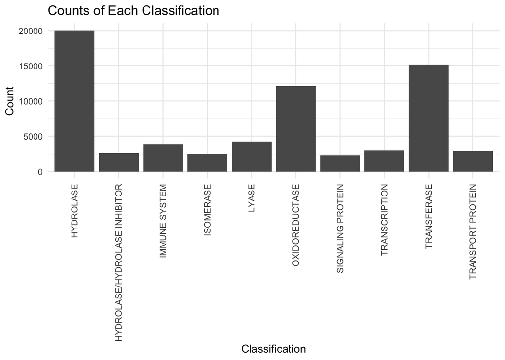

```r
ggplot(protein_data, aes(x = classification)) +
  geom_bar() +
  theme_minimal() +
  theme(axis.text.x = element_text(angle = 90, vjust = 0.5, hjust=1)) +
  labs(title = "Counts of Each Classification",
       x = "Classification",
       y = "Count")
```

It is clear that `HYDROLASE`, `OXIDOREDUCTASE`, and `TRANSFERASE` are extremely over-represented in this dataset. This is an indication that we should down-sample these three variables to prevent the model from being biased.

# Recipe

### Split data

We’re going to split our data in this step. After setting a random seed, so our results can be replicated, we split our data at an 80-20 (80% training, 20% testing) ratio. We can get away with a higher training proportion due to the sheer number of observations we have.

```r
set.seed(1234)
# create training and test datasets
protein_split <- initial_split(protein_data, prop = 0.8, strata = classification)
protein_train <- training(protein_split)
protein_test <- testing(protein_split)
```

```r
dim(protein_train)
```

```
## [1] 55122     7
```

```r
dim(protein_test)
```

```
## [1] 13781     7
```

### K-fold cross validation

K-fold cross-validation is a resampling method used to look at the performance of a machine learning model. The training dataset is split into `k` folds, or groups, at random. The model is trained on `k-1` folds and then validated on the last `k`th set. This process is repeated `k` times, using a different validation set each time. The final metrics are an average of all of the folds. This method reduces the possibility of overfitting. It makes sure that every observation is used to train and test the data. This methodology reduces the amount of variance a single observation can have on a model. Typically one chooses `k=5` or `k=10` because they achieve a good bias-variance tradeoff. We’re going to choose `k=5`. We are also going to stratify the cross validation based on `classification` because our outcome has inbalanced classes. Stratifying will help reduce bias and variance for each fold.

```r
# k-fold cross validation
cv_folds <- vfold_cv(protein_train, v = 5, strata = classification)
```

### Create recipe

Since we are using the same predictors and preprocessing steps for all five of our models, we are going to create a “recipe” that will adequately prepare our data for us to be applied to the models.

```r
# create recipe
protein_recipe <- recipe(classification ~ residue_count + resolution +
                           structure_molecular_weight + density_matthews +
                           density_percent_sol, data = protein_train) %>%
  step_normalize(all_predictors()) %>%
  step_downsample(classification, under_ratio = 2) %>%
  step_pca(residue_count, structure_molecular_weight,
           num_comp = 1, prefix = "rc_smw_component")
```

Here is what is going on step by step:

1. We define our predictors and response variable, along with the dataset we are using to train our data (`protein_train`).
2. We center and scale all of our predictors.
3. We perform downsampling to account for the imbalanced response classes.
4. PCA is done on `residue_count` and `structure_molecular_weight`, and one component named `rc_smw_component` is extracted to replace the two predictors.

### Prep and bake recipe

Prepping and baking the recipe is an intermediate step that is done to make sure all of the operations performed in the recipe are done correctly. Most bugs will be caught in this stage.

```r
# prep and bake
protein_recipe %>%
  prep() %>%
  bake(new_data = protein_train)%>%
  head()
```

```
## # A tibble: 6 × 5
##   resolution density_matthews density_percent_sol classification
##        <dbl>            <dbl>               <dbl> <fct>
## 1     0.113            0.0904              0.392  HYDROLASE
## 2    -0.0592          -0.185              -0.0613 HYDROLASE
## 3     0.783            0.342               0.720  HYDROLASE
## 4     1.19             1.29                1.67   HYDROLASE
## 5     1.17             1.10                1.50   HYDROLASE
## 6     0.400            2.23                2.20   HYDROLASE/HYDROLASE INHIBITOR
## # ℹ 1 more variable: rc_smw_component1 <dbl>
```

# Apply models

Now that we have our recipe set up, we are going to train our models. The performance metric used in this report is `roc_auc` which is used to measure the performance of a classification model. The graph is called a Receiver Operating Characteristic (ROC) curve, which plots sensitivity versus specificity. Sensitivity tells us what proportion of the actual positives were correctly identified, while specificity tells us what proportion of the actual negatives were incorrectly identified as positives. The area under the curve (AUC) measures the area under the ROC curve. A value of 0.5 means the model is completely random, while a value of 1 means the model perfectly predicts the values.

### K-nearest neighbors

K-nearest neighbors is a simple machine learning algorithm that, in simple terms, categorizes items based on the items that are most similar to it. There is one parameter we are going to “tune” which is `k`. Tuning is a step used to determine the best parameter value for a model, `k` in this case. This works by performing k-fold cross validation on each parameter value given in the “grid” of tuning values. In this case, we are going from 1-10 neighbors.

```r
# knn
knn_mod <- nearest_neighbor(neighbors = tune()) %>%
  set_mode("classification") %>%
  set_engine("kknn")

knn_wf <- workflow() %>%
  add_model(knn_mod) %>%
  add_recipe(protein_recipe)

knn_grid <- grid_regular(neighbors(range = c(1, 10)), levels = 10)

knn_results <- tune_grid(
  knn_wf,
  resamples = cv_folds,
  grid = knn_grid
)
```

Here is exactly what was done in this cell:

1. The k-nearest neighbor classification model is defined.
2. The corresponding workflow is defined where the model and recipe are added.
3. A tuning grid is defined, basically a list of values from 1 to 10, for all of the possible `k` values.
4. The model is tuned with our workflow, 5-fold cross validation, and our tuning grid.

```r
show_best(knn_results, metric = 'roc_auc')
```

```
## # A tibble: 5 × 7
##   neighbors .metric .estimator  mean     n std_err .config
##       <int> <chr>   <chr>      <dbl> <int>   <dbl> <chr>
## 1        10 roc_auc hand_till  0.641     5 0.00176 Preprocessor1_Model10
## 2         9 roc_auc hand_till  0.639     5 0.00173 Preprocessor1_Model09
## 3         8 roc_auc hand_till  0.637     5 0.00178 Preprocessor1_Model08
## 4         7 roc_auc hand_till  0.634     5 0.00171 Preprocessor1_Model07
## 5         6 roc_auc hand_till  0.630     5 0.00142 Preprocessor1_Model06
```

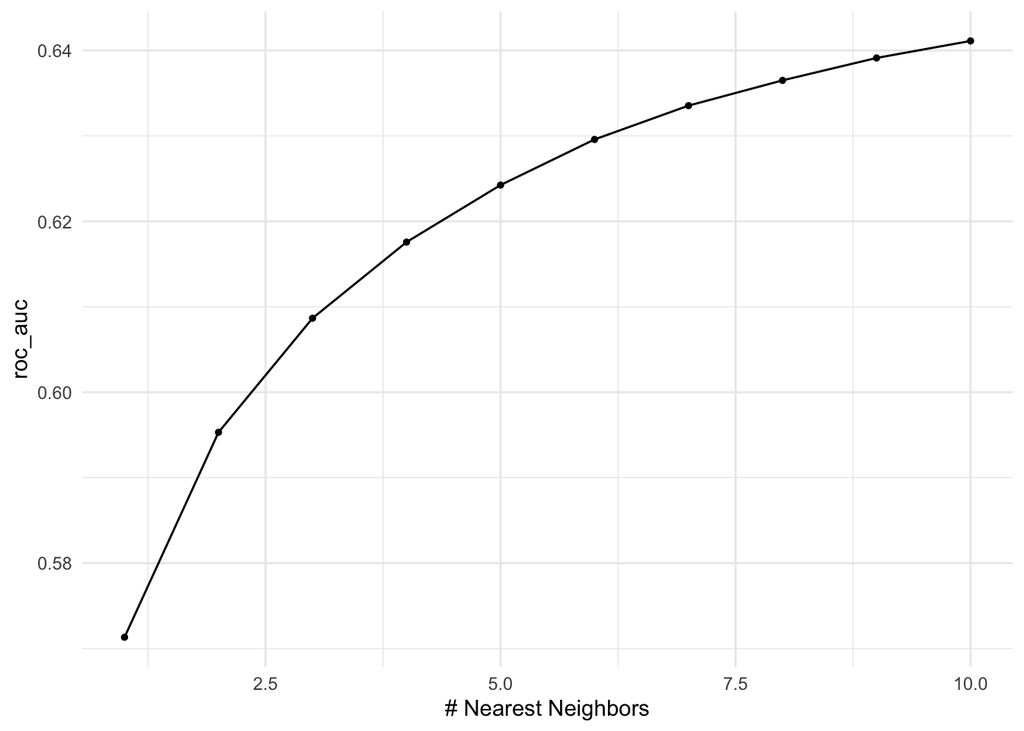

```r
autoplot(knn_results, metric = 'roc_auc') + theme_minimal()
```

Clearly, a value of `k=10` neighbors is best for our data. The ROC AUC is `0.641`, which is not too good.

### Elastic net

Elastic net is a combination of Lasso (L1 regularization) and Ridge regression (L2 regularization). The `penalty` argument tells us how much regularization the model is going to use. The `mixture` argument is the balance between the two types of regularization. A value of `mixture=1` means the model is only using Lasso (L1 regularization).

```r
# elastic net
en_mod <- multinom_reg(penalty = tune(), mixture = tune()) %>%
  set_engine("glmnet") %>%
  set_mode("classification")

en_wf <- workflow() %>%
  add_model(en_mod) %>%
  add_recipe(protein_recipe)

en_grid <- grid_regular(penalty(range = c(0, 1),
                                     trans = identity_trans()),
                        mixture(range = c(0, 1)),
                             levels = 10)

en_results <- tune_grid(
  en_wf,
  resamples = cv_folds,
  grid = en_grid
)
```

Here is what is done in this cell:

1. The elastic net classification model is defined
2. The corresponding workflow is defined where the model and recipe are added
3. A tuning grid is defined with `penalty` and `mixture` ranging between 0 and 1.
4. The model is tuned with our workflow, 5-fold cross validation, and our tuning grid.

Let’s take a look at our results:

```r
show_best(en_results, metric = 'roc_auc')
```

```
## # A tibble: 5 × 8
##   penalty mixture .metric .estimator  mean     n std_err .config
##     <dbl>   <dbl> <chr>   <chr>      <dbl> <int>   <dbl> <chr>
## 1       0   1     roc_auc hand_till  0.599     5 0.00105 Preprocessor1_Model091
## 2       0   0.778 roc_auc hand_till  0.599     5 0.00106 Preprocessor1_Model071
## 3       0   0.111 roc_auc hand_till  0.599     5 0.00105 Preprocessor1_Model011
## 4       0   0.444 roc_auc hand_till  0.599     5 0.00106 Preprocessor1_Model041
## 5       0   0.667 roc_auc hand_till  0.599     5 0.00105 Preprocessor1_Model061
```

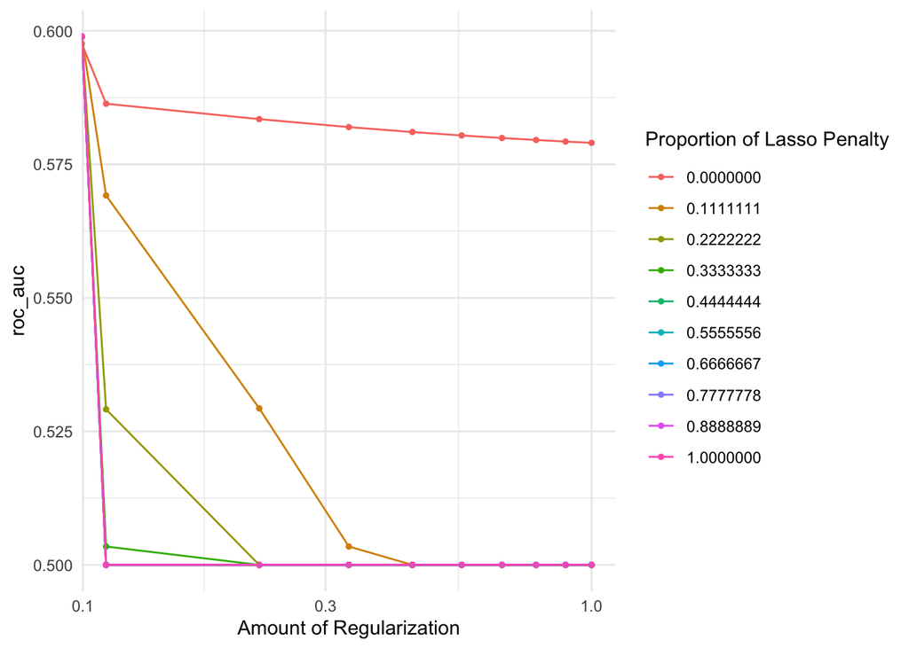

```r
autoplot(en_results, metric = 'roc_auc') + theme_minimal()
```

The best performing model has `penalty=0` and `mixture=1`. This means that there is no regularization going on, meaning the model is a standard logistic regression model. The ROC AUC of the best model here is `0.598`.

### Multinomial logistic regression

Multinomial logistic regression works like linear regression, where you have a line/plane that predicts values. However this model predicts probabilities instead of continuous values. The multinomial component comes in because logistic regression only works for binary classification problems, so a few things are changed for non-binary cases. There is no parameters that need to be tuned in this case.

```r
# logistic regression
log_mod <- multinom_reg(penalty = 0) %>%
  set_engine("glmnet") %>%
  set_mode("classification")

log_wf <- workflow() %>%
  add_model(log_mod) %>%
  add_recipe(protein_recipe)

log_results <- fit_resamples(
  object = log_wf,
  resamples = cv_folds
)
```

Here is what is done in this cell:

1. The multinomial logistic regression classification model is defined.
2. The corresponding workflow is defined where the model and recipe are added.
3. The 5-fold cross validation is performed.

Let’s see how our model performed:

```r
show_best(log_results, metric = 'roc_auc')
```

```
## # A tibble: 1 × 6
##   .metric .estimator  mean     n std_err .config
##   <chr>   <chr>      <dbl> <int>   <dbl> <chr>
## 1 roc_auc hand_till  0.599     5 0.00105 Preprocessor1_Model1
```

These results align very closely with the elastic net results. The best elastic net model was basically a multinomial regression model with an ROC AUC of `0.598`. The model here has the exact same ROC AUC all the way to 7 decimal places. Once again, this model is not the best performer.

### Random forest

Random forest models are a collection of many decision trees, a forest, each of which is built from a random subset of the data and features. Each tree in the forest makes its own decision. Each tree will vote for a class and the class with the most votes becomes the model’s prediction. There are three parameters we need to tune in this case:

- `mtry` is an integer for the number of randomly selected predictors sampled at each split in a tree.
- `trees` is the number of trees in the forest.
- `min_n` is the minimum number of data points needed for a split in a tree.

```r
rf_mod <- rand_forest(mtry = tune(),
                      trees = tune(),
                      min_n = tune()) %>%
  set_engine("ranger", importance = "impurity") %>%
  set_mode("classification")

rf_grid <- grid_regular(mtry(range = c(1, 4)),
                        trees(range = c(200, 600)),
                        min_n(range = c(10, 20)),
                        levels = 10)

rf_wf <- workflow() %>%
  add_model(rf_mod) %>%
  add_recipe(protein_recipe)
```

```r
# this chunk is run in a separate `.r` file to make knitting faster
rf_results <- tune_grid(
  rf_wf,
  resamples = cv_folds,
  grid = rf_grid
)
```

Here is what is done in this cell:

1. The random forest classification model is defined.
2. A tuning grid is created for `mtry`, `trees`, and `min_n`.
3. The corresponding workflow is defined where the model and recipe are added.
4. The model is tuned with the defined workflow, cross validation folds, and tuning grid. This step is done in a separate `.r` file due to the computation time.

Let’s load our tuning results and see the results.

```r
# load tuning results
rf_results <- readRDS("rf_tuning_results.rds")

show_best(rf_results, metric = 'roc_auc')
```

```
## # A tibble: 5 × 9
##    mtry trees min_n .metric .estimator  mean     n std_err .config
##   <int> <int> <int> <chr>   <chr>      <dbl> <int>   <dbl> <chr>
## 1     4   600    18 roc_auc hand_till  0.760     5 0.00238 Preprocessor1_Model3…
## 2     4   511    13 roc_auc hand_till  0.760     5 0.00236 Preprocessor1_Model1…
## 3     4   600    14 roc_auc hand_till  0.759     5 0.00240 Preprocessor1_Model2…
## 4     4   555    17 roc_auc hand_till  0.759     5 0.00233 Preprocessor1_Model3…
## 5     4   511    17 roc_auc hand_till  0.759     5 0.00213 Preprocessor1_Model3…
```

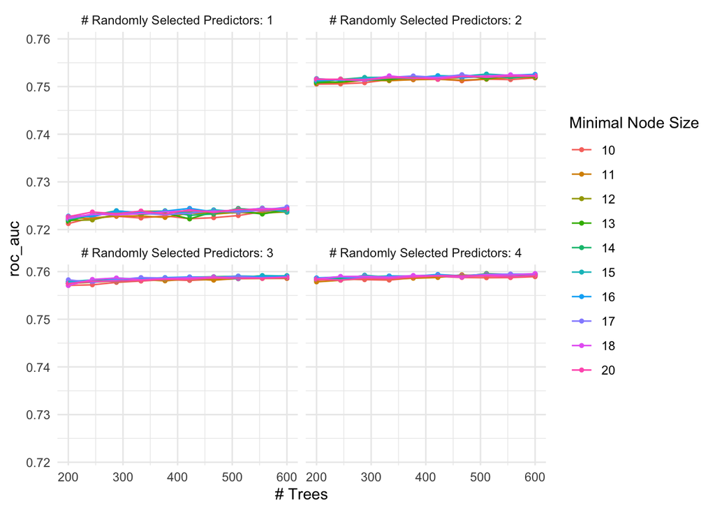

```r
autoplot(rf_results, metric = 'roc_auc') + theme_minimal()
```

The best model had `mtry=4`, `min_n=18`, and `trees=600` with an ROC AUC of `0.759`. The trend is quite clear in the chart above. Changing the number of randomly selected predictors, `mtry`, had the biggest impact on ROC AUC, but there was not much difference between 3 and 4 randomly selected predictors. Node size, `min_n`, did not play much of a role and there is a slightly positive relation with the number of trees, `trees`. This model performed quite well.

### Boosted tree

Boosted tree models are somewhat similar to random forests because they make use of many decision trees. However, each tree is built sequentially unlike random forests. In a process called “boosting”, each new tree learns from the mistakes of the previous trees. There are three parameters that we need to tune again:

- `mtry` is an integer for the number of randomly selected predictors sampled at each split in a tree.
- `trees` is the number of trees in the forest.
- `learn_rate` is the rate at which the boosting algorithm works from generation to generation.

```r
bt_mod <- boost_tree(mtry = tune(),
                     trees = tune(),
                     learn_rate = tune()) %>%
  set_engine("xgboost") %>%
  set_mode("classification")

bt_grid <- grid_regular(mtry(range = c(1, 4)),
                        trees(range = c(200, 600)),
                        learn_rate(range = c(-10, -1)),
                        levels = 10)

bt_wf <- workflow() %>%
  add_model(bt_mod) %>%
  add_recipe(protein_recipe)
```

```r
# this chunk is ran in a separate `.r` file to make knitting faster
bt_results <- tune_grid(
  bt_wf,
  resamples = cv_folds,
  grid = bt_grid
)
```

Let’s load our tuning results and see the results.

```r
bt_results <- readRDS("bt_tuning_results.rds")
show_best(bt_results, metric = 'roc_auc')
```

```
## # A tibble: 5 × 9
##    mtry trees learn_rate .metric .estimator  mean     n std_err .config
##   <int> <int>      <dbl> <chr>   <chr>      <dbl> <int>   <dbl> <chr>
## 1     3   600        0.1 roc_auc hand_till  0.752     5 0.00169 Preprocessor1_M…
## 2     3   555        0.1 roc_auc hand_till  0.752     5 0.00161 Preprocessor1_M…
## 3     3   511        0.1 roc_auc hand_till  0.752     5 0.00167 Preprocessor1_M…
## 4     3   466        0.1 roc_auc hand_till  0.752     5 0.00166 Preprocessor1_M…
## 5     3   422        0.1 roc_auc hand_till  0.751     5 0.00168 Preprocessor1_M…
```

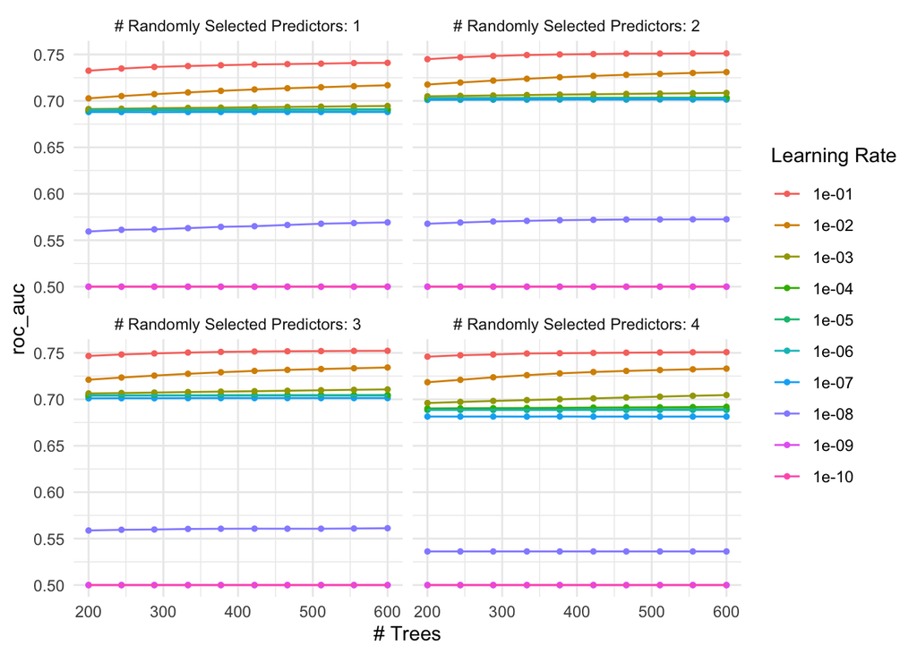

```r
autoplot(bt_results, metric = 'roc_auc') + theme_minimal()
```

The best model had `mtry=3`, `learn_rate=0.1`, and `trees=600` with an ROC AUC of `0.752`. It is clear that larger learning rates result in higher ROC AUC scores. All of the `m_try` and `tree` values seemed to have worked about the same, with `tree` having a slightly positive trend. This was another well performing model.

# Fitting the final model

Let’s see what our ROC AUC is:

```r
roc_auc(final_test, truth = classification, .pred_HYDROLASE:`.pred_TRANSPORT PROTEIN`)
```

```
## # A tibble: 1 × 3
##   .metric .estimator .estimate
##   <chr>   <chr>          <dbl>
## 1 roc_auc hand_till      0.769
```

The testing ROC AUC is a little higher than our training ROC AUC at `0.769`. This suggests that the model generalizes well and does not overfit.

Let’s create a variable importance plot (VIP) to see what variables are the most useful:

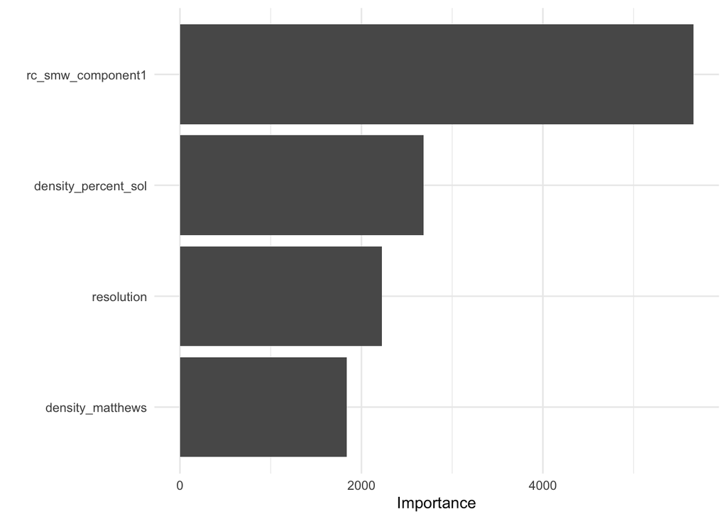

```r
final_fit %>% extract_fit_parsnip() %>%
  vip() +
  theme_minimal()
```

Now let’s see how accurately each protein type was predicted:

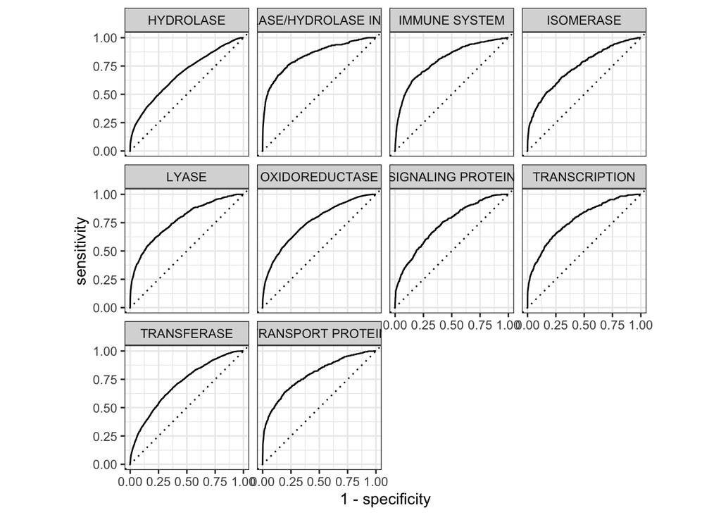

```r
roc_curve(final_test, truth = classification,
          .pred_HYDROLASE:`.pred_TRANSPORT PROTEIN`) %>%
  autoplot()
```

Most protein types were predicted quite well. However `HYDROLASE` and `TRANSFERASE` did not perform as well as the other response classes.

# Conclusion

Through this entire process from cleaning the data to training the models, the random forest algorithm is best at predicting protein type based off X-Ray diffraction measurements. The ROC AUC for the training data was `0.759`, and the testing ROC AUC was `0.769`. Even though this isn’t an excellent model, it does successfully predict protein type without overfitting. In the future, trying more folds in cross-validation is something that could be worth exploring due to the size of the dataset. On top of this, trying other classification models like LDA, QDA, and support vector machines (SVMs) are also worth exploring to see if the training ROC AUC of `0.759` can be beaten. Overall, this project was an amazing experience that taught the full machine learning pipeline.